# Multiomics analysis identifies VPA-induced changes in neural progenitor cells, ventricular-like regions, and cellular microenvironment in dorsal forebrain organoids

Zeynep Yentür, Kseniia Sarieva, Lizia Branco, Theresa Kagermeier, Christina Kulka, Mohamed A. Jarboui, Katharina Becker, Simone Mayer

Multiomics analysis identifies VPA-induced changes in neural progenitor cells, ventricular1 like regions, and cellular microenvironment in dorsal forebrain organoids

Zeynep Yentür1,2,3,4, Kseniia Sarieva2,3,4, Lizia Branco7, Theresa Kagermeier2,4, Christina Kulka6, Mohamed A. Jarboui5, Katharina Becker2, Simone Mayer*1,2,7,8

Affiliations 7 1. The Heidelberg Academy of Sciences and Humanities, Heidelberg, Germany 8 2. Hertie Institute for Clinical Brain Research, University of Tübingen, Tübingen, Germany 9 3. International Max Planck Research School, Graduate Training Centre of Neuroscience, University of Tübingen, Tübingen, Germany 11 4. Graduate Training Centre of Neuroscience, University of Tübingen, Tübingen, Germany 12 5. Core Facility for Medical Proteomics, Institute for Ophthalmic Research, University Clinic Tübingen, Tübingen, Germany 14 6. University of Tübingen, Tübingen, Germany 15 7. Zoological Institute, Karlsruhe Institute of Technology (KIT), Germany 16 8. Institute of Biological and Chemical Systems - Functional Molecular Systems, Karlsruhe Institute of Technology (KIT), Germany 18 *Correspondence: simone.mayer@kit.edu

## Abstract

Pharmaceutical agents, such as antiepileptic medications, can cross fetal barriers and affect the developing brain. Prenatal exposure to the antiepileptic drug valproate (VPA) is associated with an increased risk of neurodevelopmental disorders, including congenital malformations and autism spectrum disorder. In animal models and neural organoids, VPA 24 has been shown to alter signaling pathways, such as Wnt pathway, providing insights into VPA-induced neurodevelopmental defects. Here, we exposed dorsal forebrain organoids to VPA for days and examined effects at the tissue, cellular, and molecular level. VPA 27 treatment disrupted ventricular-like regions, indicating defects in cell-cell and cell-matrix interactions. Transcriptomics analysis confirmed altered expression of extracellular matrix (ECM) genes and single cell RNA sequencing analysis identified genes involved in microenvironment sensing, such as cellular mechanosensing and Hippo-YAP/TAZ signaling pathway. Finally, proteomics analysis corroborated that VPA alters the microenvironment of the human dorsal forebrain organoids by disrupting the secretion of ECM proteins. Altogether, our study suggests that VPA-treated dorsal forebrain organoids serve as a model to investigate the role of extracellular processes in brain development and to understand how their disruptions might contribute to neurodevelopmental disorders.

## Introduction

Environmental factors, including maternal medications, have been implicated in shaping early brain development <sup>1</sup>. Some antiepileptic drugs (AEDs), such as Levetiracetam (LEV), are considered non-teratogenic and safe for use during pregnancy <sup>2</sup>. However, other medications that can pass maternal and fetal barriers might increase the risk of neurodevelopmental and/or psychiatric disorders <sup>1</sup>. For example, valproate (VPA), an AED, is a well-known teratogen that passes the barriers and reaches the fetal brain <sup>3–5</sup>. In utero exposure to VPA, especially in the first trimester, is associated with increased risk of congenital malformations, such as neural tube closure defects, and neurodevelopmental disorders, such as autism spectrum disorder (ASD)<sup>6, 7</sup>. Despite its known teratogenic effects, VPA treatment may be continued during pregnancy when it is the only effective treatment for seizure control in patients who do not respond to other AEDs <sup>8</sup>. Since the use of VPA is unavoidable in some cases of pregnancies of epileptic patients, understanding the mechanism by which VPA disrupts neurodevelopment is crucial to develop strategies to mitigate the risk. In utero exposure to VPA is a common environmentally induced animal model of autism spectrum disorder (ASD)<sup>9</sup>. Rodents prenatally exposed to VPA display ASD-like behavioral phenotypes such as reduced sociability and repetitive hyperactivity combined with reduced exploratory activity <sup>10–13</sup>. This animal model also provides a tool to study the neurobiology of VPA-induced ASD and VPA-induced structural malformations in the nervous system. Findings show that VPA results in dysregulated differentiation of neural progenitor cells <sup>14</sup> and excitation/inhibition imbalance <sup>15</sup>. Additionally, the expression level of collagens was increased in the medial prefrontal cortex of rats prenatally exposed to VPA <sup>16</sup>. A possible mechanism that might induce these changes is through epigenetic effect of VPA as a histone deacetylase inhibitor (HDACi)<sup>17</sup>. However, animal models are limited in understanding the VPA-induced ASD pathophysiology and the effects of VPA on the developing human brain due to interspecies differences <sup>18</sup>. Human induced pluripotent stem cell (iPSC)- and embryonic stem cell (ESC)-derived neural organoids provide an in vitro model system to investigate the mechanisms of environmental exposures in neurodevelopment <sup>1, 19, 20</sup> and developmental defects in ASD <sup>21, 22</sup> in a human-specific tissue context. Various neural organoid protocols have been developed, including regionalized protocols such as dorsal forebrain organoids (DFOs), which recapitulate important features of the cellular, molecular, and cytoarchitectural features of specific regions of the human brain <sup>23, 24</sup>. Human neural organoids have been utilized to study the effects VPA exposure and its potential link to ASD <sup>25–27</sup>. Independent studies have shown that VPA treatment altered ventricular zone (VZ)-like structures and progenitors, and impaired differentiation in neural organoids <sup>26–30</sup>. While these studies have provided insights into the cellular and transcriptional changes induced by VPA 74 exposure, they have not investigated how microenvironment components, such as extracellular matrix (ECM) are altered in a human tissue context. In this study, we used human iPSC-derived DFOs to examine the cellular and molecular effects of VPA exposure during early neocortical development. We treated the organoids with VPA from day (D)21 of differentiation until D50 to recapitulate continuous exposure of progenitor cells to VPA at early stages of their expansion and neural differentiation. Using immunohistochemistry, we found that VPA exposure disrupted the VZ-like structures, possibly by disrupting the cellular microenvironment. We identified changes in intracellular

ProLong Gold (Thermofisher Scientific, Cat. no. P36930). For epifluorescence imaging of whole organoid sections, Leica DMi8 microscope was used with 20x or 40x magnification objectives. For confocal imaging of VZ-like structures, Zeiss LSM710 confocal microscope, Leica SP8 confocal microscope was used with 40x magnification objective. Quantification of IHC analysis Imaging of Ki67+ cells were performed on randomly selected VZ-like regions in the dorsal forebrain organoid slice. Using Imaris 9.7 software, all confocal images were rotated, adjusted with “Surfaces” tool and cropped to obtain 50 µm-wide VZ-like regions. Then, by using “Spots” tool cells that were positive for both Ki67 and SOX2 markers were quantified. The exact number of VZ-like regions quantified for each treatment condition can be found in the respective figure legends. Quantification of the number and size of VZ-like structures were performed with ImageJ. The whole DFO section was used to count the total number and area of VZ-like regions. Polygon selection tool was used to mark each VZ-like region using SOX2+ vRG cells, then total number of polygons created, and the area of each polygon was quantified in ImageJ. Quantification of cCas3+ area over SOX2+ VZ-like area was performed using custom macro in ImageJ. In short, first VZ-like regions were cropped in ImageJ using SOX2+ vRG cells as reference. The macro would first detect the SOX2+ area within the VZ-like region and crop the image where SOX2 signal is positive, then identify the cCas3+ and SOX2+ double positive area to generate percentage cCas3+ area over SOX2+ VZ-like region. Quantification of Vimentin signal was performed using custom macro in ImageJ. In short, segmented line selection tool with defined width was used to mark the edge of all the organoid images taken at 20x magnification. Then, mean gray value in the selected region was quantified for vimentin signal at the organoid edges. RNA isolation and bulk RNA sequencing RNA isolation from organoids was performed by using the RNeasy Mini Kit (Qiagen, Cat. No. 197 74106) and RNase- Free DNase set (Qiagen, Cat. no. 79254) with RNAase-free water. Library preparation for bulk RNA sequencing was performed by Novogene (https://en.novogene.com/) using non-directional poly-A enrichment strategy. Samples were sequenced with Illumina NovaSeq platform using paired-end, 150-bp-long reads to million reads per sample. Further quality control measures and bioinformatics analysis were performed by Novogene. For detection of significantly differentially expressed genes (DEGs) from differential gene expression analysis, two criteria were used: <sup>1</sup> absolute Fold change > 1.5 and <sup>2</sup> padj ≤ 205 0.05 between Ctrl and VPA treatment conditions. For further GO enrichment analysis of upregulated and downregulated DEGs, online RNA-seq bioinformatics analysis tool of Novogene called NovoMagic was used. All expressed genes present in the dataset was used as background for enrichment analysis. Further plotting of the data was performed on R 209 using custom scripts. Layer-specific analysis and plotting was performed using custom R script following the method published in Miller et al. <sup>32</sup>. For enrichment human fetal PCW15-16 microarray data from Allen Institute was used. Fisher’s exact test was used for statistics with the Benjamini-Hochberg for multiple comparisons.

Weighted gene co-expression analysis (WGCNA) was performed by Novogene. NovoMagic was used for further GO enrichment analysis of eigengene modules generated by Novogene. Custom script in R were used to visualize GO analysis and WGCNA module network using the gene names as nodes and connectivity between genes as size of each node. Single cell RNA sequencing Single cell dissociation and multiplexing for single cell RNA sequencing Following a published protocol (Velasco et al.) with minor modifications, individual dorsal forebrain organoids were dissociated into single cells using Worthington Papain Dissociation System kit (Worthington Biochemical, Cat. no. LK003150). In short, organoids of interest were washed twice with PBS and then incubated with Papain supplemented with DNase inhibitor for mins at 37°C on orbital shaker. Then, organoids were gently triturated 15 225 times using mL pipette tip and returned to incubation minutes, repeated twice. Single cells were transferred to a tube containing Ovomucoid Inhibitor diluted in Earle’s medium supplemented with DNase inhibitor and centrifuged at g for minutes in room temperature. Cell pellet was resuspended in 0.04% BSA in PBS, filtered through 40 µm cell strainer (Flowmi) and counted using an automatic fluorescent cell counter (Luna). Single cell suspensions were centrifuged at rcf for minutes at room temperature. The cell pellet was resuspended in Cell Multiplexing Oligos from 3' CellPlex Kit Set A (10x Genomics, Cat. no. PN-1000261) and multiplexing protocol from manufacturer was performed. Finally, multiplexed cells were counted and pooled in equal proportions to be proceeded with single cell RNA sequencing pipeline by CeGat Tübingen. Approximately 14 000 cells per channel were loaded to Chromium chip (10x Genomics) and processed through the Chromium controller. Sequencing libraries were generated using Chromium Next GEM 238 Single Cell 3' Kit, v3.1 (10x Genomics) and sequenced on NovaSeq (Illumina). Single-cell data analysis Quality control and data preprocessing CellRanger (v.7.1.0) multi pipeline was used to align reads to the prebuild 10x Genomics GRCh38-2020-A reference genome including introns and generate cell-by-gene matrices. Data were analyzed in R (v4.3.2) using Seurat (5.0.3)<sup>33</sup>. Ambient RNA was removed with CellBender (v0.2.0) with false discovery rate (FDR) = 0.01 and epochs = 150 <sup>34</sup>. The following thresholds were chosen for removing low-quality cells: min number of genes per cell – 2000, max number of reads per cell – 50000, max percentage of mitochondrial reads per cell – 8%, min percentage of ribosomal protein coding genes – 4%, min log10(genes per UMI) – 0.8. DoubletDetection (v4.2) under default parameters was employed to remove potential doublets <sup>35</sup>. Following these filters, a total of 37,326 cells were retained with an average of 16,842 transcripts per cell and average 5,159 genes per cell. Raw gene counts were normalized per sample using the SCTransform workflow while regressing out the number of genes, the number of reads, and percentage of mitochondrial and ribosomal RNAs. Different samples were then integrated using reciprocal principal component analysis as implemented in Seurat v5. Linear dimensionality reduction was performed using PCA, and we selected first PCs for further clustering and non-linear dimensionality reduction based on the Elbow plot. UMAP plots were generated using the Seurat package with a number of neighbors set to 15. Louvain clustering was performed across several resolutions, and resolution 0.6 was chosen based on clustree (0.5.1) cluster stability assessment <sup>36</sup>. Cluster

marker analysis using the FindAllMarkers function with both MAST <sup>37</sup> and roc algorithms were utilized as an initial guidance for cluster annotations. Additionally, we assessed the expression of canonical genes to assign each cluster to a known cell type. Removal of non-telencephalic and stressed cells The VoxHunt algorithm was used to assess the regional identity of individual clusters, and SCTransform expression values were used as input. E18 mouse transcriptional profiles were used as a reference for identifying regional identity. A cluster that did not show similarity to the forebrain was filtered from the dataset. After excluding non-telencephalic cells, the Gruffi (1.5.5) algorithm was applied to identify and remove cells exhibiting a transcriptional signature of cellular stress. This was done using an automatic threshold at the 0.9 quantile for two stress-related GO terms - GO:0034976 (Response to ER stress) and GO:0006096 (Glycolytic process) - and two non-stress-related GO terms - GO:0042063 (Gliogenesis) and GO:0022008 (Neurogenesis). After removing non272 telencephalic and stressed cells, the dataset was subjected to normalization, integration, clustering (with resolution 0.4), dimensionality reduction, and annotation workflow as mentioned above. Cell proportion analysis Differences in cell type proportions between experimental conditions were analyzed with a permutation test followed by bootstrapping (https://github.com/rpolicastro/scProportionTest), where clusters with absolute log2 Fold change > 0.58 and FDR < 0.05 were considered differentially abundant. Trajectory inference and trajectory quality assessment For this section and subsequent steps of the analysis of the single-cell RNA-seq data, updated versions of R (v.4.4.1) and Seurat (v.5.1.0) were utilized. For trajectory inference, cells belonging to excitatory lineage were subset, normalized, integrated, and plotted into reduced dimensions. Monocle (v.1.3.7) algorithm was applied to construct putative single285 cell differentiation trajectories based on the UMAP representation <sup>38, 39</sup>. The start of the trajectory was set in the RG cell type. A random forest classifier was used to retrieve genes differentially expressed along the putative deep-layer neuron differentiation trajectory. Identification of differentially expressed genes, gene module signatures, and GO enrichment analysis To identify differentially expressed genes (DEGs) between experimental conditions by cell type, we performed a differential gene expression (DGE) analysis using the edgeR package (v.4.2.2). A minimum threshold of cells per sample for each cell type was applied. Three pseudo-replicates were generated for each sample and cell type by splitting the cells into three groups and summing the gene expression values within each group. Low-expression genes were excluded using the filterByExpr function, and differences in library sizes across samples were normalized with calcNormFactors. Dispersion estimates for each gene were calculated using estimateDisp, and a negative binomial generalized log-linear model was fitted to the gene counts with glmQLFit. Genes with absolute log2 Fold change > 1.5 and FDR < 0.0001 and were considered statistically significant. GO enrichment analysis was conducted for both upregulated and downregulated genes using the enrichGO function from the clusterProfiler R package (v.4.12.6), with an adjusted

gradient from 2% to 30 % of buffer B (80% acetonitrile and 0.08% formic acid in HPLC-grade water) in buffer A (2% acetonitrile and 0.1% formic acid in HPLC-grade water) at a flow rate of nl per min. The remaining peptides were eluted by a short gradient from 30% to 95% 392 buffer B; the total gradient run was min. Spectra were acquired in Data Independent Acquisition (DIA) mode using variable-width windows over the mass range 350-1500 m/z, MS2 scan range was set from to m/z. Mass spectrometry data analysis and statistics MS RAW data were analyzed using DIA-NN 1.8.1 (PMID: 31768060) in library-free mode against the human database (UniProt release September 2023). First, a precursor ion library was generated using FASTA digest for library-free search in combination with deep learning399 based Spectra prediction. An experimental library generated from the DIA-NN search was used for cross-run normalization and Mass accuracy correction. Only high-accuracy spectra with a minimum precursor false discovery rate (FDR) of 0.01, and only tryptic peptides (2 402 missed Tryptic cleavages) were used for protein quantification. The match between runs option was activated and no shared spectra were used for protein identification. Statistical analysis, including label-free quantification ratios (LFQ), and two-sided corrected permutation-based T-test (250 permutations and a minimum p-value of 0.05) to identify putative differentially abundant proteins between the two groups was done using the Perseus software suite version 1.6.15.0 (PMID: 27348712). The analytical platform Omics Playground (https://github.com/bigomics/omicsplayground) was used for proteomics data exploration and integration. Principle component analysis (PCA) plots and volcano plots were generated using the built411 in functions within the Perseus software. For PCA plot of proteome and secretome, data before data imputation was used. For the rest of the analysis, data imputation was performed separately for each cell line and time point by replacing missing values with values from normal distribution. Custom codes in RStudio software were generated for heatmaps and GO analysis. To analyze and visualize proteins, we used gene symbols. 416 pheatmap library was used for heatmaps with “Euclidean” as clustering distance for rows and averaged log2 transformed LFQ values were used as input for the heatmaps. Finally, overrepresentation analysis (ORA) for GO terms was performed using topGO library and parameters used for enrichGO function were as follows: reference gene list=org.Hs.eg.db, minGSSize=10, maxGSSize=500, p value=0.05, q value=0.10 and p adjusted method = FDR. All proteins that were found in at least two samples were used as background for GO 422 enrichment analysis. Further adjustments to the plots were made using Inkscape software. Statistical analysis Statistical analyses were performed in GraphPad Prism software or by using custom scripts in R/Python. The details of each statistical analysis performed can be found in the respective figure legend.

## Results

Dose-dependent alterations in dorsal forebrain organoids are evident upon exposure to VPA, but not Levetiracetam

With the aim of investigating how environmental factors affect neocortical development, we differentiated a range of healthy control iPSC lines into dorsal forebrain organoids <sup>23</sup>. To investigate the effects of different AEDs and their concentration-dependent biological effects, we treated DFOs with VPA (teratogenic AED) and LEV (non-teratogenic AED) at concentrations of 0.1, 0.5, and mM from D21 of differentiation until D35 (Fig. S1A). These concentrations are in the clinically relevant therapeutic range for epilepsy treatment <sup>45</sup>, and similar ranges were used in other neural organoid studies <sup>25–29</sup>. We chose to start treatment from D21 targeting neural progenitors and early neural differentiation, mirroring the increased risk for neurodevelopmental disorders upon exposure in the first trimester of pregnancy <sup>46</sup>. Throughout the treatment period, organoid growth was monitored using brightfield microscopy (Fig. S1B). At D35, VPA-treated organoids were smaller than control (Ctrl) organoids upon mM VPA treatment. However, this effect was not clearly observed at lower concentrations (Fig. S1C). No change in organoid size was observed at any LEV 443 concentration at any time point (Fig. S1C). To determine whether the smaller size of VPA444 treated organoids was due to reduced proliferation in the VZ-like regions, we assessed the proliferative state of ventricular radial glia (vRG) by quantifying Ki67-SOX2 co-expressing proliferative radial glia (RG) cells over SOX2+ total RG cells in VZ-like region cropped to 50 447 μm-width (Fig. S1D). We found fewer proliferative RG cells upon VPA treatment on D35 in a concentration-dependent manner, where mM VPA-treated organoids had significantly fewer proliferative vRG cells (Fig. S1E). We did not observe any significant reduction in proliferative vRG cells at any LEV concentrations (Fig. S1E). To determine whether cell death also contributed to the smaller size of these organoids, we quantified the percentage of cCas3+ apoptotic vRG cell area over a 50 μm-wide SOX2+ VZ-like region area (Fig. S1F). No significant difference was observed between the VPA-treated and Ctrl groups, indicating that apoptosis of vRG cells does not drive the reduced size at D35 (Fig. S1G). Since RG cells are the main cell type driving proliferation and organoid growth at D35, we decided to focus solely on this cell type for proliferation and apoptosis analysis. Collectively, these results suggest that VPA treatment alters the neurodevelopmental trajectory of DFOs by reducing the proportion of proliferative cells, in line with other VPA-treated organoid and animal models <sup>26, 28, 47</sup>. As expected, we did not see significant changes upon LEV treatment, which is known as a non-teratogenic AED treatment. To understand the teratogenic mechanisms of VPA treatment we solely focused on VPA-treated DFOs in further analyses. Long-term exposure to VPA disrupts DFO growth and alters the structure of ventricular463 like zones To investigate the long-term effects of VPA on DFOs, we decided to use mM VPA, as this concentration successfully mimicked the developmental defects without inducing apoptosis in vRG cells. Hence, mM VPA was continuously added to the organoid culture media from D21 to D50 to focus on the early neurogenesis (Fig. 1A). Organoid growth was monitored with bright-field microscopy throughout the treatment period (Fig. 1B) and revealed that Ctrl organoids exhibited continuous growth over the culture period, while VPA-treated organoids ceased growing around day (Fig. 1C). Size comparison between VPA-treated and Ctrl organoids revealed significant differences at both D35 and D50 (Fig. 1D). Furthermore, we visualized (Fig. 1E, S2A) and quantified the proliferative vRG using Ki67473 SOX2 co-expressing cells over SOX2+ total RG cells at D50 (Fig. 1F). VPA-treated organoids had significantly less proliferating vRG cells compared to the Ctrl organoids at D50 (Fig. 1F).

Figure 1

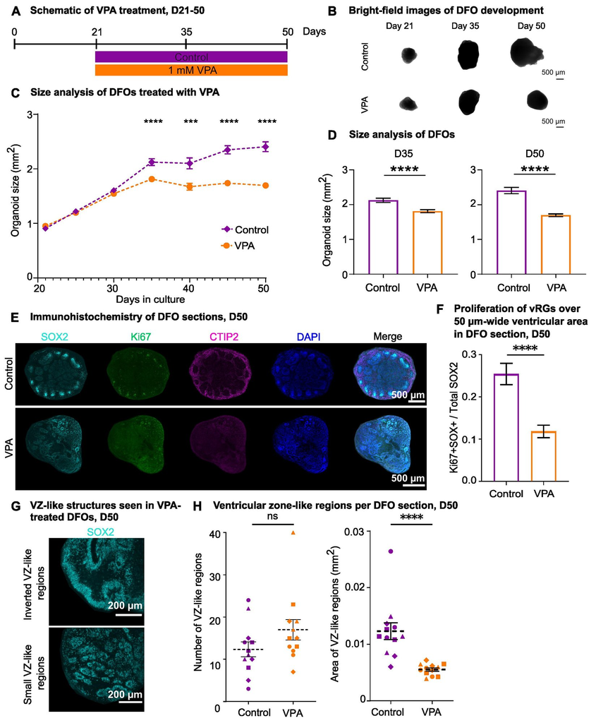

**Fig. 1: Dorsal forebrain organoids to study the effects of long-term exposure to VPA.** (A) Schematic of VPA treatment D21–50. (B) Brightfield images. (C) Size over time. (D) Size at D35/D50. (E) IHC: SOX2, Ki67, CTIP2. (F) Proliferative RG cells. (G) Disrupted VZ-like regions. (H) VZ-like region number and area.

Figure 2

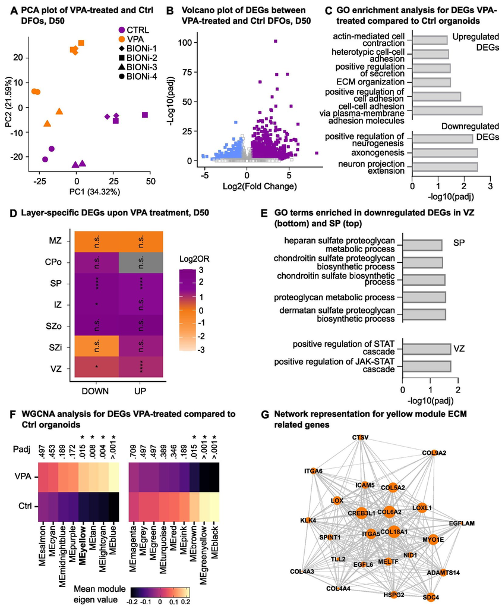

**Fig. 2: Bulk RNA-sequencing to identify changes in DFO transcriptome upon VPA exposure.** (A) PCA plot. (B) Volcano plot. (C) GO enrichment. (D) Layer-specific enrichment. (E) VZ/SP GO terms. (F) WGCNA heatmap. (G) Yellow module network.

results suggest that VPA-treated organoids were stalled in their development compared to Ctrl organoids. Different cell types show differential susceptibility to VPA treatment To identify cell-type-specific changes in the transcriptome upon VPA treatment, we performed DGE analysis on transcriptomic clusters. We excluded Cajal-Retzius cells because they did not meet the threshold of a minimum number of cells per organoid and performed DGE analysis on the remaining cell types (Fig. 4A). We identified more than 400 571 upregulated DEGs in RG cells, IPC/newborn ExN, young dExN, and mature dExN (significance threshold: absolute log2 Fold change > 1.5 and false discovery rate (FDR) < 0.0001) (Fig. 4B, 573 4C). We then performed enrichment analysis using upregulated and downregulated DEGs for each cell type. The young ExN cluster had significant upregulation of GO terms related to Wnt signaling pathway. Meanwhile, the mature dExN cluster had significant upregulation of GO terms related to dorsal/ventral patterning. Upon VPA treatment, neither yielded significant downregulated biological processes GO terms. For further analysis, we decided to focus on the progenitor cell types, RG and IPC, as these cell types were significantly over579 represented in VPA-treated organoids. 426 genes were upregulated, and genes were downregulated in RG in organoids treated with VPA compared to the Ctrl organoids (Fig. 581 4D). Overrepresentation analysis (ORA) using upregulated DEGs from RG cells identified upregulation of BP terms related to cell adhesion, synaptic membrane adhesion, and exocytosis-related terms in VPA-treated organoids compared to Ctrl (Fig. 4E). On the other hand, genes were upregulated, and genes were downregulated in the IPC/newborn ExN cluster in VPA-treated organoids compared to the Ctrl organoids (Fig. S5D). Similar to the RG cluster, ORA using upregulated DEGs from IPC/newborn ExNs identified BPs related to cell adhesion, synapse organization, vesicle fusion, and exocytosis in VPA-treated organoids compared to Ctrl (Fig. S5E). Downregulated DEGs from both RG and IPC/newborn ExNs did not yield any significant GO terms. These results indicate altered extracellular secretion and intercellular communication in VPA-treated organoids. To explore this hypothesis in more detail, we used CellChat to compare two different types of molecular interactions in VPA vs. Ctrl: ECM-receptor interactions and cell-cell contact interactions in RG cells (Fig. 4F, Fig. S5F). In both cases, interaction strength was notably reduced in VPA compared to Ctrl organoids (Fig. 4F, Fig. S5F). We identified reduced information flow in ECM proteins such as collagen and laminin upon VPA treatment (Fig. 4F) and reduced information flow in synaptic adhesion molecules such as neurexin and NCAM (Fig. S5F). To understand the mechanism behind this change, we compared the expression of individual genes in the RG cluster from pathways that are likely to be involved in ECM interactions and cell adhesion (Fig. 4G). These pathways included PIEZO, Hippo signaling, integrin-FAK signaling, and cytoskeleton. We identified that upon VPA treatment, PIEZO1 channel expression was increased. Meanwhile, the overall expression of Hippo and integrin-FAK signaling pathway elements was decreased, suggesting changes in the ECM-receptor interactions in the RG cluster (Fig. 4G).

Figure 3

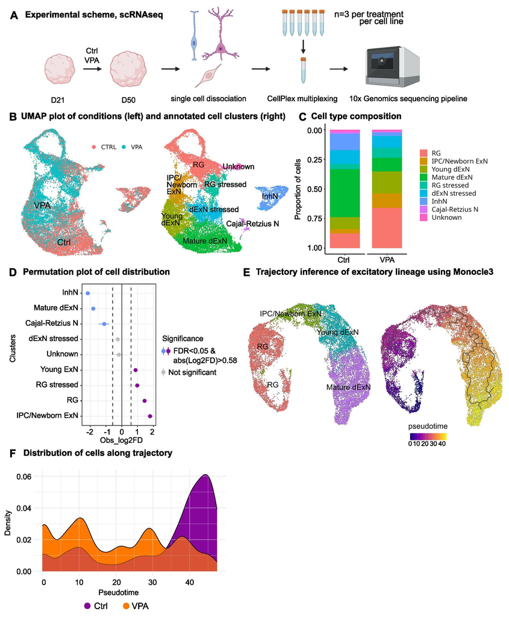

**Fig. 3: Single cell RNA-sequencing to determine affected cell types upon VPA treatment.** (A) Experimental scheme. (B) UMAP by condition and cell type. (C) Cell type composition. (D) Permutation test. (E) Monocle3 trajectory. (F) Pseudotime density.

Figure 4

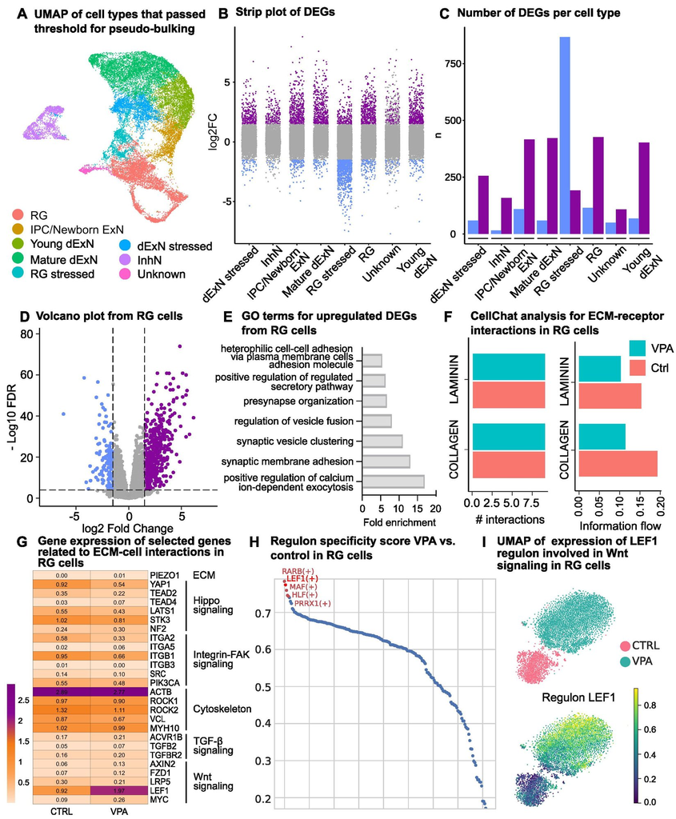

**Fig. 4: Single cell RNA-sequencing to analyze cell-type differential effects of VPA treatment.** (A) Cell types in DGE. (B) DEG strip plot. (C) DEG counts. (D) RG volcano plot. (E) GO enrichment. (F) CellChat. (G) Signaling heatmap. (H) SCENIC regulons. (I) LEF1 expression.

Figure 5

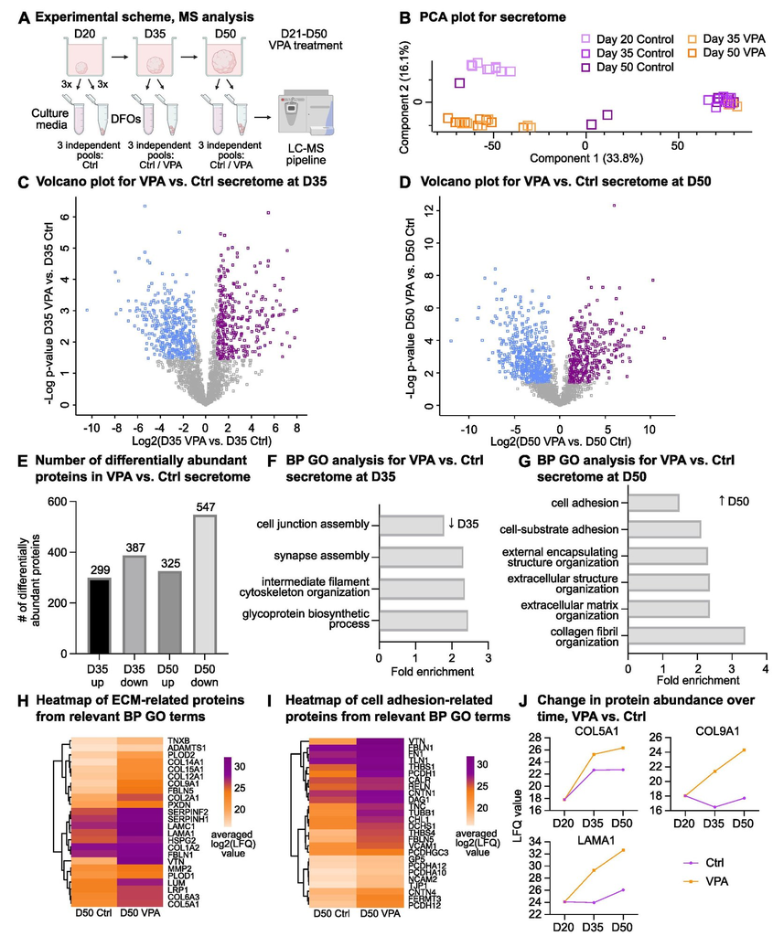

**Fig. 5: Secretome analysis of DFOs treated with VPA compared to Ctrl.** (A) Experimental scheme. (B) PCA. (C-D) Volcano plots. (E) Protein counts. (F-G) GO enrichment. (H-I) ECM/adhesion heatmaps. (J) Protein abundance over time.

## Discussion

Prenatal exposure to VPA is a well-known risk factor for neurodevelopmental disorders. This study mimicked early neurodevelopmental defects associated with prenatal VPA exposure using human iPSC-derived DFOs. Leveraging a multi-omics approach by combining several types of transcriptomic and proteomic analyses, we found an accumulation of ECM 659 components in the microenvironment and dysregulation of mechanosensitive signaling pathways, especially in RGs. Hence, we highlight the link between intracellular dysregulation induced by VPA, most likely at the epigenetic level, and extracellular consequences and how they lead to the neurodevelopmental defects, an aspect that has been underexplored in previous human models of prenatal VPA exposure. Previous studies on VPA-treated organoids have reported similar findings, including reduced organoid size and proliferation, and alterations in ventricular-like structures <sup>26, 28, 29</sup>. A 666 closer look at their transcriptomics data also identified upregulation of extracellular structure-related terms <sup>25, 54</sup>. Altogether, despite differences in experimental paradigms, such as different organoid protocols, VPA concentrations, and treatment durations, these studies consistently reported similar neurodevelopmental disruptions, highlighting the robustness of VPA-induced defects. Similar to our findings, Zang et al. observed that VPA 671 inhibited progenitor proliferation and reduced neural differentiation, as well as identified upregulation of genes related to the Wnt signaling pathway <sup>26</sup>, which was also upregulated in our scRNA-seq data. They showed that blockers of Wnt pathway rescued VPA-induced defects such as surface area, ventricular-like structure thickness, neural progenitor proliferation, and neurogenesis <sup>26</sup>. Interestingly, it was previously shown that the Wnt/β-catenin pathway is responsive to ECM stiffness <sup>55, 56</sup>, which could link upregulated ECM genes to the increased expression of Wnt signaling genes observed by both Zang et al. and us. We therefore emphasize the role of the microenvironment in neurodevelopment and highlight how defects in extracellular interactions contribute to neurodevelopmental disorders. ECM accumulation in the cellular microenvironment and disrupted cellular mechanosensing ECM is one of the main components of the cellular microenvironment and it provides mechanical and structural support to the cells as well as regulating the local availability of signaling molecules <sup>57</sup>. ECM accumulation in the microenvironment may lead to increased ECM stiffness and thus influence cell-ECM interactions and cellular mechanosensing. Cell687 ECM interactions can affect mechanosensing in two parallel pathways: integrin receptors and the integrin-based focal adhesion kinase (FAK) signaling pathway, and piezo channels <sup>58, 59</sup>. Integrins are cell adhesion transmembrane proteins that link the ECM to the cytoskeleton, which allows them to transduce signals between cells and their

microenvironment <sup>60</sup>. This signaling is mediated by FAK, which is a key downstream signaling mediator of integrins upon activation <sup>60</sup>. Integrin-FAK signaling components, including ITGA2, ITGB1, and ITGB3 as well as SRC were downregulated in VPA-treated DFOs, indicating a defective mechanotransduction (Fig. 4G). In line with our findings, it was previously shown that VPA treatment blocked the interaction between renal carcinoma cells and ECM by altering integrin expression and blocking FAK signaling <sup>61, 62</sup>. VPA is a histone deacetylase inhibitor (HDACi), which alters expression of genes through epigenetic regulation <sup>63</sup>. A possible epigenetic alteration of the integrin signaling pathway components upon VPA treatment can explain the decreased expression of integrin receptors, which may amplify ECM accumulation. PIEZO1 expression was increased in VPA-treated DFOs (Fig. 4G), likely as a response to increased ECM in the microenvironment. Piezo channels are calcium channels that allow calcium flow into the cell depending on mechanical changes in the microenvironment <sup>54</sup>. This calcium influx then activates various intracellular signaling pathways that influence processes such as growth and migration <sup>64</sup>. In a preprint, ECM stiffening was shown to reduce proliferation, impair differentiation and induce accumulation of transitional alveolar progenitor cells via mechanosensing <sup>65</sup>. These transitional cell states were associated with fibrotic remodeling and senescence <sup>65</sup>. Thus, increased ECM components alter mechanical properties of the microenvironment and affect cellular mechanosensing. Hippo-YAP/TAZ signaling pathway dysregulation and quiescent/senescent cellular state Different cellular inputs including mechanical signals, such as cell-cell contact and ECM 712 stiffness can influence Hippo-YAP/TAZ signaling pathway, which regulates processes such as organ size by controlling proliferation/differentiation dynamics <sup>66</sup>. In our dataset, disruptions in Hippo pathway components were observed, with reduced YAP1 and TEAD2 715 expression (Fig. 4G), which might indicate mechanosensing defects. It has been shown that YAP/TAZ are required to maintain the proliferative potential and structural organization of cortical RG cells <sup>67</sup>. Meanwhile, loss of YAP/TAZ resulted in increased cell cycle length of RG cells, therefore reducing the proliferative capacity, and resulting in reduced number of cortical projection neurons <sup>67</sup>. In line with this finding, reduced YAP1 expression in VPA720 treated DFOs may explain overrepresentation of progenitor cells and underrepresentation of neuronal cells through increased cell cycle length or a possible shift towards transitional progenitor state due to incomplete RG to neuron differentiation. Upon performing SCENIC analysis on RG cells, we identified upregulation of LEF1, a transcription factor associated with quiescent adult neural stem cell gene regulation <sup>68</sup>. VPA could potentially increase the activity of LEF1 regulon by increasing its chromatin accessibility and drive radial glia cells into quiescence. Both quiescence and senescence are states of cell cycle arrest, and they have been proposed to represent a continuum of cell cycle withdrawal <sup>69</sup>. Previously, decreased proliferation and increased senescent markers were observed in neuroepithelial cells in VPA-treated neural organoids <sup>28</sup> and VPA-treated neural tube organoids <sup>70</sup>. ECM stiffening, such as through increased collagen, was shown to be one of the hallmarks of senescent cells <sup>71</sup>. In line with this notion, our pseudotime analysis revealed an arrest at various cell states along the excitatory lineage (Fig. 3F). Thus,

VPA might induce or prolong a transitional cellular state in progenitors, in which these cells then enter senescence or quiescence. Structural changes in VZ-like regions in DFOs and its neurodevelopmental implications Altogether, our data reveals accumulation of ECM proteins in the microenvironment and defects in mechanosensing pathways, which likely result in disrupted VZ-like structures and associated neurodevelopmental implications. Consistent with our findings, Zhang et al. 739 demonstrated that VPA exposure induces irregularly shaped neural rosettes with reduced diameters compared to Ctrl organoids modelling neural tube defects <sup>72</sup>. Similarly, VPA 741 treatment was used to model the risk of neural tube defects in human spinal cord organoids <sup>73</sup>. Furthermore, VPA treatment of DFOs may be used to recapitulate the cortical malformations seen in ASD patients. For example, the reduced size of our DFOs upon VPA 744 treatment could mimic microcephaly observed in some ASD patients <sup>74</sup>. Therefore, in vitro VPA exposure of neural organoids offers an environmentally induced human model of ASD, providing a platform to study ASD pathophysiology in human tissue. Altogether, ECM 747 components may be a therapeutic target for ASD, as modulation of the microenvironment has potential to restore molecular, cellular, and structural alterations. ECM-based interventions may offer a more accessible treatment option compared to treatments that target intracellular pathways. In this study, we provide a comprehensive transcriptomic and proteomic profile of VPA752 treated DFOs during early neural development. To our knowledge, this is the first neural organoid study to perform a comparative secretome analysis of VPA treatment in organoids. Our findings demonstrate that VPA treatment disrupts the microenvironment and cellular mechanosensing, potentially exacerbating their defects in a feedback loop. This disruption in ECM and cell-ECM interactions leads to impaired RG proliferation, defects in VZ-like structures, and disrupted neurogenesis. Therefore, this model can serve as a platform to study the effects of environmental adversities on the microenvironment and give new insights into the mechanisms of neurodevelopmental disorders. Limitations of the study While we intentionally treated the organoids from D21 to D50 to capture changes in progenitor populations and early neuronal differentiation, this time frame does not provide information on later neurodevelopmental processes, such as neuronal maturation and synaptic activity. Additionally, although we employed a broad range of techniques, such as scRNA-seq and LC-MS, these methods have inherent limitations. For instance, scRNA-seq offers detailed insights into cellular states but lacks spatial context, while mass spectrometry is a bulk method that does not provide cell-type-specific proteomic changes or spatial information. In future studies, a new method called secretion encoded single-cell sequencing (SEC-seq) could be utilized to link the transcriptome of each cell with its secretome on a single-cell level <sup>75</sup>. Furthermore, functional validation experiments are required to understand a possible causal relationship between ECM accumulation and changes in mechanosensing pathways following VPA treatment.

## Data availability

RNA sequencing, single cell RNA sequencing and MS data will be accessible in datatype775 specific repositories.

## Acknowledgments

This study was funded by the WIN Program of the Heidelberg Academy of Sciences and Humanities, financed by the Ministry of Sciences, Research, and the Arts of the State of Baden-Württemberg (to SM) and Hertie Foundation (to SM). This project was also partially funded by the Brain & Behavior Research Foundation (NARSAD Young Investigator Grant 781 27026 to SM), the Baden-Württemberg state postgraduate fellowship (to KS and TK), Add782 on Fellowship of the Joachim Herz Foundation (to KS), and the Daimler and Benz Foundation (32-06/20, to SM). We thank the German Research Foundation (DFG) for supporting the acquisition of the confocal microscope used in this study (INST 37/1170-1 FUGG, project number 467868227). This research has been partially funded by the Deutsche Forschungsgemeinschaft (DFG, German Research Foundation) under Germany’s Excellence Strategy via the Excellence Cluster 3D Matter Made to Order (EXC-2082/1 – 390761711 to SM and LB). We thank Elisabeth Gustafsson for her technical support. We thank all the student assistants for their technical support. We thank Core Facility for Medical Proteomics, especially Franziska Klose, for protein isolation and mass spectrometry support. We thank Dr. Nicolas Snaidero and his lab members for the confocal microscopy support. We thank Dr. Christian Mahringer, Dr. Henner Koch and Prof. Dr. Yvonne Weber for fruitful discussions. Conflict of interests No competing interests were declared by the authors.

## Author contributions

ZY designed the study, performed experiments, data analysis, statistical analysis, and prepared the manuscript; KS, MAJ, TK, and KB performed experiments; KS, LB, CK, and MAJ 799 performed data analysis; all authors revised the manuscript; SM conceived and designed the study, supervised the work, and prepared the manuscript.

## References

1. Sarieva K, Mayer S. The Effects of Environmental Adversities on Human Neocortical Neurogenesis Modeled in Brain Organoids. *Front Mol Biosci.* 2021;8:686410.
2. Chaudhry SA, Jong G, Koren G. The fetal safety of Levetiracetam: a systematic review. *Reprod Toxicol.* 2014;46:40-5.
3. Lucke A, et al. Simultaneous and continuous measurement of free concentration of valproate in blood and extracellular space of rat cerebral cortex. *Epilepsia.* 1994;35(5):922-6.
4. Jackson BL, et al. Investigating the effects of valproic acid on placental epigenetic modifications and development in the CD-1 mouse model. *Reprod Toxicol.* 2024;124:108551.
5. Lloyd KA. A scientific review: mechanisms of valproate-mediated teratogenesis. *Bioscience Horizons.* 2013;6.
6. Coste J, et al. Risk of early neurodevelopmental disorders associated with in utero exposure to valproate and other antiepileptic drugs. *Sci Rep.* 2020;10(1):17362.
7. Bromley RL, et al. The prevalence of neurodevelopmental disorders in children prenatally exposed to antiepileptic drugs. *J Neurol Neurosurg Psychiatry.* 2013;84(6):637-43.
8. Valproic Acid. MotherToBaby | Fact Sheets. Brentwood (TN)1994.
9. Jiao D, et al. Establishment of animal models and behavioral studies for autism spectrum disorders. *J Int Med Res.* 2024;52(4):3000605241245293.
10. Nicolini C, Fahnestock M. The valproic acid-induced rodent model of autism. *Exp Neurol.* 2018;299(Pt A):217-27.
11. Kim KC, et al. The critical period of valproate exposure to induce autistic symptoms in Sprague-Dawley rats. *Toxicol Lett.* 2011;201(2):137-42.
12. Schneider T, Przewlocki R. Behavioral alterations in rats prenatally exposed to valproic acid. *Neuropsychopharmacology.* 2005;30(1):80-9.
13. Fereshetyan K, et al. Assessment of behavioral, morphological and electrophysiological changes in valproate induced rat models of ASD. *Sci Rep.* 2021;11(1):23471.
14. Jung GA, et al. Valproic acid induces differentiation and inhibition of proliferation in neural progenitor cells. *BMC Cell Biol.* 2008;9:66.
15. Kim KC, et al. Pax6-dependent cortical glutamatergic neuronal differentiation regulates autism-like behavior. *Mol Neurobiol.* 2014;49(1):512-28.
16. Olde Loohuis NFM, et al. Altered expression of circadian rhythm and extracellular matrix genes in a valproic acid rat model of autism. *Prog Neuropsychopharmacol Biol Psychiatry.* 2017;77:128-32.
17. Fukuchi M, et al. Valproic acid induces up- or down-regulation of gene expression in rat cortical neurons. *Neurosci Res.* 2009;65(1):35-43.
18. Muotri AR. The Human Model: Changing Focus on Autism Research. *Biol Psychiatry.* 2016;79(8):642-9.
19. Yan Y, et al. High-quality models for assessing the effects of environmental pollutants: 3D brain organoids. *Ecotoxicol Environ Saf.* 2024;284:116876.
20. Huang Y, et al. Long-term exposure to cadmium disrupts neurodevelopment in mature cerebral organoids. *Sci Total Environ.* 2024;912:168923.
21. Jourdon A, et al. Modeling idiopathic autism in forebrain organoids. *Nat Neurosci.* 2023;26(9):1505-15.
22. Li C, et al. Single-cell brain organoid screening identifies developmental defects in autism. *Nature.* 2023;621(7978):373-80.
23. Velasco S, et al. Individual brain organoids reproducibly form cell diversity of the human cerebral cortex. *Nature.* 2019;570(7762):523-7.
24. Pasca SP, et al. A nomenclature consensus for nervous system organoids and assembloids. *Nature.* 2022;609(7929):907-10.
25. Meng Q, et al. Human forebrain organoids reveal connections between valproic acid exposure and autism risk. *Transl Psychiatry.* 2022;12(1):130.
26. Zang Z, et al. Valproic acid exposure decreases neurogenic potential of outer radial glia in human brain organoids. *Front Mol Neurosci.* 2022;15:1023765.
27. Cui K, et al. Neurodevelopmental impairment induced by prenatal valproic acid exposure with the human cortical organoid-on-a-chip model. *Microsystems & Nanoengineering.* 2020;6(1):49.
28. Rhinn M, et al. Aberrant induction of p19Arf-mediated cellular senescence contributes to neurodevelopmental defects. *PLoS Biol.* 2022;20(6):e3001664.
29. Kelava I, et al. Androgens increase excitatory neurogenic potential in human brain organoids. *Nature.* 2022;602(7895):112-6.
30. Tidball AM, et al. Deriving early single-rosette brain organoids from human pluripotent stem cells. *Stem Cell Reports.* 2023;18(12):2498-514.
31. Kunze C, et al. Synthetic AAV/CRISPR vectors for blocking HIV-1 expression in persistently infected astrocytes. *Glia.* 2018;66(2):413-27.
32. Miller JA, et al. Transcriptional landscape of the prenatal human brain. *Nature.* 2014;508(7495):199-206.
33. Hao Y, et al. Dictionary learning for integrative, multimodal and scalable single-cell analysis. *Nature Biotechnology.* 2023.
34. Fleming SJ, et al. Unsupervised removal of systematic background noise using CellBender. *Nature Methods.* 2023;20(9):1323-35.
35. Gayoso A, Shor J. DoubletDetection v4.2. Zenodo. 2022.
36. Zappia L, Oshlack A. Clustering trees. *GigaScience.* 2018;7(7).
37. Finak G, et al. MAST: a flexible statistical framework for single-cell RNA sequencing data. *Genome Biology.* 2015;16(1).
38. Trapnell C, et al. The dynamics and regulators of cell fate decisions are revealed by pseudotemporal ordering. *Nature Biotechnology.* 2014;32(4):381-6.
39. Cao J, et al. The single-cell transcriptional landscape of mammalian organogenesis. *Nature.* 2019;566(7745):496-502.
40. Abrahams BS, et al. SFARI Gene 2.0. *Mol Autism.* 2013;4(1):36.
41. lab SA. List of human transcription factors (hg38). SCENIC Protocol GitHub repository.
42. lab SA. Human hg38 RefSeq r80 gene-based motif collection (mc9nr).
43. Kennedy SA, et al. Extensive rewiring of the EGFR network in colorectal cancer cells. *Nat Commun.* 2020;11(1):499.
44. Shahinuzzaman ADA, et al. Improved in-solution trypsin digestion method. *J Sep Sci.* 2020;43(11):2125-32.
45. Schwertheim S, et al. Valproic acid downregulates NF-kappaB p50 activity. *Horm Metab Res.* 2014;46(3):181-6.
46. Fietz AK, et al. Impact of maternal first trimester treatment regimen on valproate exposed pregnancies. *Sci Rep.* 2024;14(1):674.
47. Lee Y, et al. Valproic acid decreases the proliferation of telencephalic cells in zebrafish larvae. *Neurotoxicol Teratol.* 2013;39:91-9.
48. Pollen AA, et al. Molecular identity of human outer radial glia during cortical development. *Cell.* 2015;163(1):55-67.
49. Sarieva K, et al. Human brain organoid model of maternal immune activation identifies radial glia cells as selectively vulnerable. *Mol Psychiatry.* 2023;28(12):5077-89.
50. Langfelder P, Horvath S. WGCNA: an R package for weighted correlation network analysis. *BMC Bioinformatics.* 2008;9:559.
51. Vertesy A, et al. Gruffi: an algorithm for computational removal of stressed cells from brain organoid transcriptomic datasets. *EMBO J.* 2022;41(17):e111118.
52. Nano PR, et al. A Meta-Atlas of the Developing Human Cortex Identifies Modules Driving Cell Subtype Specification. *bioRxiv.* 2023.
53. Lee JE, et al. Canonical Wnt signaling through Lef1 is required for hypothalamic neurogenesis. *Development.* 2006;133(22):4451-61.
54. Xu Y, et al. Piezo1: the key regulators in central nervous system diseases. *Front Cell Neurosci.* 2024;18:1441806.
55. Barbolina MV, et al. Matrix rigidity activates Wnt signaling through down-regulation of Dickkopf-1 protein. *J Biol Chem.* 2013;288(1):141-51.
56. Du J, et al. Extracellular matrix stiffness dictates Wnt expression through integrin pathway. *Sci Rep.* 2016;6:20395.
57. Sainio A, Jarvelainen H. Extracellular matrix-cell interactions. *Cell Signal.* 2020;66:109487.
58. Yamada KM, et al. Cell-3D matrix interactions: recent advances and opportunities. *Trends Cell Biol.* 2022;32(10):883-95.
59. He J, et al. Mechanical stiffness promotes skin fibrosis via Piezo1-Wnt2/Wnt11-CCL24 positive feedback loop. *Cell Death Dis.* 2024;15(1):84.
60. Pang X, et al. Targeting integrin pathways: mechanisms and advances in therapy. *Signal Transduct Target Ther.* 2023;8(1):1.
61. Jones J, et al. Valproic acid blocks adhesion of renal cell carcinoma cells. *J Cell Mol Med.* 2009;13(8B):2342-52.
62. Juengel E, et al. Effects of combined valproic acid and AEE788 on renal cell carcinoma cell lines. *BJU Int.* 2010;105(4):549-57.
63. Mello MLS. Sodium Valproate-Induced Chromatin Remodeling. *Front Cell Dev Biol.* 2021;9:645518.
64. Duan J, et al. PIEZO1 Affects Cell Growth and Migration via Microfilament-Mediated YAP trans-Latitudinal Regulation. *Anal Chem.* 2025;97(1):147-56.
65. Ahmed DW, et al. Local photo-crosslinking of native tissue matrix regulates cell function. *bioRxiv.* 2024.
66. Terry BK, Kim S. The role of Hippo-YAP/TAZ signaling in brain development. *Dev Dyn.* 2022;251(10):1644-65.
67. Lavado A, et al. YAP/TAZ maintain the proliferative capacity and structural organization of radial glial cells. *Dev Biol.* 2021;480:39-49.
68. Garcia-Corzo L, et al. The transcription factor LEF1 interacts with NFIX and switches isoforms during adult hippocampal neural stem cell quiescence. *Front Cell Dev Biol.* 2022;10:912319.
69. Ashraf HM, et al. The intensities of canonical senescence biomarkers integrate the duration of cell-cycle withdrawal. *Nat Commun.* 2023;14(1):4527.
70. Pietrogrande G, et al. Valproic acid-induced teratogenicity is driven by senescence and prevented by Rapamycin. *Mol Psychiatry.* 2024.
71. Mavrogonatou E, et al. Senescence-associated alterations in the extracellular matrix. *Am J Physiol Cell Physiol.* 2023;325(3):C633-C47.
72. Zhang XZ, et al. Folic Acid Rescues Valproic Acid-Induced Morphogenesis Inhibition in Neural Rosettes. *Front Cell Neurosci.* 2022;16:888152.
73. Lee JH, et al. Transcriptional Signature of Valproic Acid-Induced Neural Tube Defects in Human Spinal Cord Organoids. *Int J Stem Cells.* 2023;16(4):385-93.
74. Fombonne E, et al. Microcephaly and macrocephaly in autism. *J Autism Dev Disord.* 1999;29(2):113-9.
75. Langerman J, et al. Linking single-cell transcriptomes with secretion using SEC-seq. *Nat Protoc.* 2025.